# Optimal Treatment Analysis

## Outcome Variable

**Outcome Variable:** haz

## Predictor Variables

**Intervention Variable:** fage

**Adjustment Set:**

- arm
- W_mage
- meducyrs
- feducyrs
- W_mhtcm
- W_mwtkg
- W_mbmi
- W_fhtcm
- single
- brthmon
- delta_W_mage
- delta_meducyrs
- delta_feducyrs
- delta_W_mhtcm
- delta_W_mwtkg
- delta_W_mbmi
- delta_W_fhtcm
- delta_single
- delta_brthmon

## Stratifying Variables

The analysis was stratified on these variable(s):

- agecat
- studyid
- country

## Data Summary

| agecat | studyid | country | fage | n_cell | n |
| --- | --- | --- | --- | --- | --- |
| Birth | ki0047075b-MAL-ED | BANGLADESH | >=38 | 63 | 133 |
| Birth | ki0047075b-MAL-ED | BANGLADESH | <32 | 25 | 133 |
| Birth | ki0047075b-MAL-ED | BANGLADESH | [32-38) | 45 | 133 |
| Birth | ki0047075b-MAL-ED | BRAZIL | >=38 | 6 | 18 |
| Birth | ki0047075b-MAL-ED | BRAZIL | <32 | 1 | 18 |
| Birth | ki0047075b-MAL-ED | BRAZIL | [32-38) | 11 | 18 |
| Birth | ki0047075b-MAL-ED | INDIA | >=38 | 7 | 27 |
| Birth | ki0047075b-MAL-ED | INDIA | <32 | 9 | 27 |
| Birth | ki0047075b-MAL-ED | INDIA | [32-38) | 11 | 27 |
| Birth | ki0047075b-MAL-ED | NEPAL | >=38 | 2 | 9 |
| Birth | ki0047075b-MAL-ED | NEPAL | <32 | 2 | 9 |
| Birth | ki0047075b-MAL-ED | NEPAL | [32-38) | 5 | 9 |
| Birth | ki0047075b-MAL-ED | PERU | >=38 | 23 | 69 |
| Birth | ki0047075b-MAL-ED | PERU | <32 | 22 | 69 |
| Birth | ki0047075b-MAL-ED | PERU | [32-38) | 24 | 69 |
| Birth | ki0047075b-MAL-ED | SOUTH AFRICA | >=38 | 17 | 31 |
| Birth | ki0047075b-MAL-ED | SOUTH AFRICA | <32 | 5 | 31 |
| Birth | ki0047075b-MAL-ED | SOUTH AFRICA | [32-38) | 9 | 31 |
| Birth | ki0047075b-MAL-ED | TANZANIA, UNITED REPUBLIC OF | >=38 | 19 | 46 |
| Birth | ki0047075b-MAL-ED | TANZANIA, UNITED REPUBLIC OF | <32 | 9 | 46 |
| Birth | ki0047075b-MAL-ED | TANZANIA, UNITED REPUBLIC OF | [32-38) | 18 | 46 |
| Birth | ki1000304b-SAS-CompFeed | INDIA | >=38 | 40 | 1249 |
| Birth | ki1000304b-SAS-CompFeed | INDIA | <32 | 1045 | 1249 |
| Birth | ki1000304b-SAS-CompFeed | INDIA | [32-38) | 164 | 1249 |
| Birth | ki1119695-PROBIT | BELARUS | >=38 | 606 | 13396 |
| Birth | ki1119695-PROBIT | BELARUS | <32 | 10729 | 13396 |
| Birth | ki1119695-PROBIT | BELARUS | [32-38) | 2061 | 13396 |
| Birth | ki1135781-COHORTS | GUATEMALA | >=38 | 245 | 823 |
| Birth | ki1135781-COHORTS | GUATEMALA | <32 | 380 | 823 |
| Birth | ki1135781-COHORTS | GUATEMALA | [32-38) | 198 | 823 |

[output cut: 75 more lines]

The following strata were considered:

- agecat: 24 months, studyid: ki0047075b-MAL-ED, country: BANGLADESH
- agecat: 24 months, studyid: ki0047075b-MAL-ED, country: BRAZIL
- agecat: 24 months, studyid: ki0047075b-MAL-ED, country: INDIA
- agecat: 24 months, studyid: ki0047075b-MAL-ED, country: NEPAL
- agecat: 24 months, studyid: ki0047075b-MAL-ED, country: PERU
- agecat: 24 months, studyid: ki0047075b-MAL-ED, country: SOUTH AFRICA
- agecat: 24 months, studyid: ki0047075b-MAL-ED, country: TANZANIA, UNITED REPUBLIC OF
- agecat: 24 months, studyid: ki1119695-PROBIT, country: BELARUS
- agecat: 24 months, studyid: ki1135781-COHORTS, country: GUATEMALA
- agecat: 24 months, studyid: ki1135781-COHORTS, country: PHILIPPINES
- agecat: 24 months, studyid: ki1148112-LCNI-5, country: MALAWI
- agecat: 6 months, studyid: ki0047075b-MAL-ED, country: BANGLADESH
- agecat: 6 months, studyid: ki0047075b-MAL-ED, country: BRAZIL
- agecat: 6 months, studyid: ki0047075b-MAL-ED, country: INDIA
- agecat: 6 months, studyid: ki0047075b-MAL-ED, country: NEPAL
- agecat: 6 months, studyid: ki0047075b-MAL-ED, country: PERU
- agecat: 6 months, studyid: ki0047075b-MAL-ED, country: SOUTH AFRICA
- agecat: 6 months, studyid: ki0047075b-MAL-ED, country: TANZANIA, UNITED REPUBLIC OF
- agecat: 6 months, studyid: ki1000304b-SAS-CompFeed, country: INDIA
- agecat: 6 months, studyid: ki1000304b-SAS-FoodSuppl, country: INDIA
- agecat: 6 months, studyid: ki1119695-PROBIT, country: BELARUS
- agecat: 6 months, studyid: ki1135781-COHORTS, country: GUATEMALA
- agecat: 6 months, studyid: ki1135781-COHORTS, country: PHILIPPINES
- agecat: 6 months, studyid: ki1148112-LCNI-5, country: MALAWI
- agecat: Birth, studyid: ki0047075b-MAL-ED, country: BANGLADESH
- agecat: Birth, studyid: ki0047075b-MAL-ED, country: BRAZIL
- agecat: Birth, studyid: ki0047075b-MAL-ED, country: INDIA
- agecat: Birth, studyid: ki0047075b-MAL-ED, country: NEPAL
- agecat: Birth, studyid: ki0047075b-MAL-ED, country: PERU
- agecat: Birth, studyid: ki0047075b-MAL-ED, country: SOUTH AFRICA
- agecat: Birth, studyid: ki0047075b-MAL-ED, country: TANZANIA, UNITED REPUBLIC OF
- agecat: Birth, studyid: ki1000304b-SAS-CompFeed, country: INDIA
- agecat: Birth, studyid: ki1119695-PROBIT, country: BELARUS
- agecat: Birth, studyid: ki1135781-COHORTS, country: GUATEMALA
- agecat: Birth, studyid: ki1135781-COHORTS, country: PHILIPPINES

### Dropped Strata

Some strata were dropped due to rare outcomes:

- agecat: Birth, studyid: ki0047075b-MAL-ED, country: BRAZIL
- agecat: Birth, studyid: ki0047075b-MAL-ED, country: NEPAL

## Methods Detail

We’re interested in the causal parameters $E[Y_a]$ for all values of $a \in \mathcal{A}$. These parameters represent the mean outcome if, possibly contrary to fact, we intervened to set all units to have $A=a$. Under the randomization and positivity assumptions, these are identified by the statistical parameters $\psi_a=E_W[E_{Y|A,W}(Y|A=a,W)]$. In addition, we’re interested in the mean of $Y$, $E[Y]$ under no intervention (the observed mean). We will estimate these parameters by using SuperLearner to fit the relevant likelihood factors – $E_{Y|A,W}(Y|A=a,W)$ and $p(A=a|W)$, and then updating our likelihood fit using a joint TMLE.

For unadjusted analyses ($W=\{\}$), initial likelihoods were estimated using Lrnr_glm to estimate the simple $E(Y|A)$ and Lrnr_mean to estimate $p(A)$. For adjusted analyses, a small library containing Lrnr_glmnet, Lrnr_xgboost, and Lrnr_mean was used.

Having estimated these parameters, we will then use the delta method to estimate relative risks and attributable risks relative to a prespecified baseline level of $A$.

# Results Detail

## Results Plots

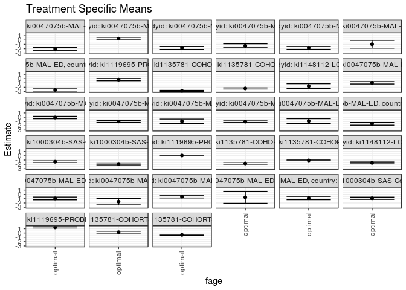

## Results Table

### Parameter: TSM

| agecat | studyid | country | intervention_level | baseline_level | estimate | ci_lower | ci_upper |
| --- | --- | --- | --- | --- | --- | --- | --- |
| Birth | ki0047075b-MAL-ED | BANGLADESH | optimal | observed | -0.9405622 | -1.2628242 | -0.6183002 |
| Birth | ki0047075b-MAL-ED | INDIA | optimal | observed | -1.6916997 | -2.4354150 | -0.9479844 |
| Birth | ki0047075b-MAL-ED | PERU | optimal | observed | -0.5170424 | -0.8322775 | -0.2018073 |
| Birth | ki0047075b-MAL-ED | SOUTH AFRICA | optimal | observed | -0.6814846 | -2.0799085 | 0.7169393 |
| Birth | ki0047075b-MAL-ED | TANZANIA, UNITED REPUBLIC OF | optimal | observed | -0.8552588 | -1.2415798 | -0.4689378 |
| Birth | ki1000304b-SAS-CompFeed | INDIA | optimal | observed | -0.9072663 | -1.1739408 | -0.6405919 |
| Birth | ki1119695-PROBIT | BELARUS | optimal | observed | 1.3068487 | 1.1473526 | 1.4663447 |
| Birth | ki1135781-COHORTS | GUATEMALA | optimal | observed | 0.1845462 | -0.0280590 | 0.3971515 |
| Birth | ki1135781-COHORTS | PHILIPPINES | optimal | observed | -0.4401691 | -0.5491110 | -0.3312273 |
| 6 months | ki0047075b-MAL-ED | BANGLADESH | optimal | observed | -0.9688599 | -1.2514909 | -0.6862289 |
| 6 months | ki0047075b-MAL-ED | BRAZIL | optimal | observed | -0.0720222 | -0.3591552 | 0.2151108 |
| 6 months | ki0047075b-MAL-ED | INDIA | optimal | observed | -0.9950938 | -1.2077886 | -0.7823989 |
| 6 months | ki0047075b-MAL-ED | NEPAL | optimal | observed | -0.9543765 | -1.4790569 | -0.4296960 |
| 6 months | ki0047075b-MAL-ED | PERU | optimal | observed | -1.0365741 | -1.2278600 | -0.8452883 |
| 6 months | ki0047075b-MAL-ED | SOUTH AFRICA | optimal | observed | -0.8964398 | -1.4438399 | -0.3490397 |
| 6 months | ki0047075b-MAL-ED | TANZANIA, UNITED REPUBLIC OF | optimal | observed | -1.5372718 | -1.8541600 | -1.2203837 |
| 6 months | ki1000304b-SAS-CompFeed | INDIA | optimal | observed | -1.3814239 | -1.5870764 | -1.1757713 |
| 6 months | ki1000304b-SAS-FoodSuppl | INDIA | optimal | observed | -1.8903904 | -2.1320067 | -1.6487741 |
| 6 months | ki1119695-PROBIT | BELARUS | optimal | observed | 0.0618913 | -0.0324154 | 0.1561980 |
| 6 months | ki1135781-COHORTS | GUATEMALA | optimal | observed | -1.7822647 | -1.9583438 | -1.6061856 |
| 6 months | ki1135781-COHORTS | PHILIPPINES | optimal | observed | -1.0789777 | -1.1716297 | -0.9863257 |
| 6 months | ki1148112-LCNI-5 | MALAWI | optimal | observed | -1.6493478 | -1.8636908 | -1.4350048 |
| 24 months | ki0047075b-MAL-ED | BANGLADESH | optimal | observed | -2.0477019 | -2.3794311 | -1.7159726 |
| 24 months | ki0047075b-MAL-ED | BRAZIL | optimal | observed | 0.3335471 | 0.0368361 | 0.6302580 |
| 24 months | ki0047075b-MAL-ED | INDIA | optimal | observed | -1.8220491 | -2.1665233 | -1.4775749 |
| 24 months | ki0047075b-MAL-ED | NEPAL | optimal | observed | -1.3280970 | -1.7757960 | -0.8803979 |
| 24 months | ki0047075b-MAL-ED | PERU | optimal | observed | -1.8217926 | -2.1553252 | -1.4882600 |
| 24 months | ki0047075b-MAL-ED | SOUTH AFRICA | optimal | observed | -0.9838741 | -1.8826334 | -0.0851148 |
| 24 months | ki0047075b-MAL-ED | TANZANIA, UNITED REPUBLIC OF | optimal | observed | -2.6367515 | -2.8971763 | -2.3763267 |
| 24 months | ki1119695-PROBIT | BELARUS | optimal | observed | -0.2321349 | -0.4970107 | 0.0327408 |
| 24 months | ki1135781-COHORTS | GUATEMALA | optimal | observed | -2.8606147 | -2.9929454 | -2.7282841 |
| 24 months | ki1135781-COHORTS | PHILIPPINES | optimal | observed | -2.2867013 | -2.4276052 | -2.1457973 |
| 24 months | ki1148112-LCNI-5 | MALAWI | optimal | observed | -1.7426710 | -2.2985907 | -1.1867513 |

### Parameter: E(Y)

| agecat | studyid | country | intervention_level | baseline_level | estimate | ci_lower | ci_upper |
| --- | --- | --- | --- | --- | --- | --- | --- |
| Birth | ki0047075b-MAL-ED | BANGLADESH | observed | observed | -1.0100752 | -1.1744939 | -0.8456565 |
| Birth | ki0047075b-MAL-ED | INDIA | observed | observed | -1.3522222 | -1.7800602 | -0.9243843 |
| Birth | ki0047075b-MAL-ED | PERU | observed | observed | -0.9334783 | -1.1468995 | -0.7200571 |
| Birth | ki0047075b-MAL-ED | SOUTH AFRICA | observed | observed | -0.7345161 | -1.1414567 | -0.3275756 |
| Birth | ki0047075b-MAL-ED | TANZANIA, UNITED REPUBLIC OF | observed | observed | -1.0947826 | -1.3988341 | -0.7907311 |
| Birth | ki1000304b-SAS-CompFeed | INDIA | observed | observed | -1.4300160 | -1.5090211 | -1.3510109 |
| Birth | ki1119695-PROBIT | BELARUS | observed | observed | 1.3357428 | 1.1757840 | 1.4957016 |
| Birth | ki1135781-COHORTS | GUATEMALA | observed | observed | 0.1377035 | 0.0520086 | 0.2233984 |
| Birth | ki1135781-COHORTS | PHILIPPINES | observed | observed | -0.2468988 | -0.2865742 | -0.2072233 |
| 6 months | ki0047075b-MAL-ED | BANGLADESH | observed | observed | -1.1980333 | -1.3314438 | -1.0646229 |
| 6 months | ki0047075b-MAL-ED | BRAZIL | observed | observed | 0.0543249 | -0.1697391 | 0.2783889 |
| 6 months | ki0047075b-MAL-ED | INDIA | observed | observed | -1.1778882 | -1.3228601 | -1.0329163 |
| 6 months | ki0047075b-MAL-ED | NEPAL | observed | observed | -0.7277004 | -0.9122329 | -0.5431679 |
| 6 months | ki0047075b-MAL-ED | PERU | observed | observed | -1.3317470 | -1.5395361 | -1.1239579 |
| 6 months | ki0047075b-MAL-ED | SOUTH AFRICA | observed | observed | -0.9078464 | -1.1231179 | -0.6925750 |
| 6 months | ki0047075b-MAL-ED | TANZANIA, UNITED REPUBLIC OF | observed | observed | -1.4744833 | -1.6639782 | -1.2849884 |
| 6 months | ki1000304b-SAS-CompFeed | INDIA | observed | observed | -1.4006377 | -1.4802862 | -1.3209891 |
| 6 months | ki1000304b-SAS-FoodSuppl | INDIA | observed | observed | -1.8986842 | -2.0118892 | -1.7854792 |
| 6 months | ki1119695-PROBIT | BELARUS | observed | observed | 0.1166130 | 0.0230160 | 0.2102100 |
| 6 months | ki1135781-COHORTS | GUATEMALA | observed | observed | -1.8068353 | -1.8758487 | -1.7378219 |
| 6 months | ki1135781-COHORTS | PHILIPPINES | observed | observed | -1.1421265 | -1.1845116 | -1.0997415 |
| 6 months | ki1148112-LCNI-5 | MALAWI | observed | observed | -1.6211321 | -1.8052501 | -1.4370141 |
| 24 months | ki0047075b-MAL-ED | BANGLADESH | observed | observed | -1.9893377 | -2.1309533 | -1.8477222 |
| 24 months | ki0047075b-MAL-ED | BRAZIL | observed | observed | 0.1366034 | -0.0878045 | 0.3610113 |
| 24 months | ki0047075b-MAL-ED | INDIA | observed | observed | -1.8803727 | -2.0319827 | -1.7287626 |
| 24 months | ki0047075b-MAL-ED | NEPAL | observed | observed | -1.5368987 | -1.7259939 | -1.3478035 |
| 24 months | ki0047075b-MAL-ED | PERU | observed | observed | -1.7017511 | -1.8926845 | -1.5108176 |
| 24 months | ki0047075b-MAL-ED | SOUTH AFRICA | observed | observed | -1.4819850 | -1.6947019 | -1.2692681 |
| 24 months | ki0047075b-MAL-ED | TANZANIA, UNITED REPUBLIC OF | observed | observed | -2.7648500 | -2.9586982 | -2.5710018 |
| 24 months | ki1119695-PROBIT | BELARUS | observed | observed | -0.1254844 | -0.4225624 | 0.1715937 |
| 24 months | ki1135781-COHORTS | GUATEMALA | observed | observed | -2.9828012 | -3.0482527 | -2.9173497 |
| 24 months | ki1135781-COHORTS | PHILIPPINES | observed | observed | -2.4204386 | -2.4659064 | -2.3749708 |
| 24 months | ki1148112-LCNI-5 | MALAWI | observed | observed | -1.7832432 | -1.9856110 | -1.5808754 |

### Parameter: PAR

| agecat | studyid | country | intervention_level | baseline_level | estimate | ci_lower | ci_upper |
| --- | --- | --- | --- | --- | --- | --- | --- |
| Birth | ki0047075b-MAL-ED | BANGLADESH | optimal | observed | -0.0695130 | -0.3175816 | 0.1785555 |
| Birth | ki0047075b-MAL-ED | INDIA | optimal | observed | 0.3394775 | -0.3170164 | 0.9959714 |
| Birth | ki0047075b-MAL-ED | PERU | optimal | observed | -0.4164359 | -0.7247753 | -0.1080964 |
| Birth | ki0047075b-MAL-ED | SOUTH AFRICA | optimal | observed | -0.0530315 | -1.3088591 | 1.2027961 |
| Birth | ki0047075b-MAL-ED | TANZANIA, UNITED REPUBLIC OF | optimal | observed | -0.2395238 | -0.6066979 | 0.1276503 |
| Birth | ki1000304b-SAS-CompFeed | INDIA | optimal | observed | -0.5227497 | -0.7577613 | -0.2877380 |
| Birth | ki1119695-PROBIT | BELARUS | optimal | observed | 0.0288941 | -0.0358218 | 0.0936099 |
| Birth | ki1135781-COHORTS | GUATEMALA | optimal | observed | -0.0468427 | -0.2453515 | 0.1516661 |
| Birth | ki1135781-COHORTS | PHILIPPINES | optimal | observed | 0.1932704 | 0.0889057 | 0.2976350 |
| 6 months | ki0047075b-MAL-ED | BANGLADESH | optimal | observed | -0.2291734 | -0.4865573 | 0.0282104 |
| 6 months | ki0047075b-MAL-ED | BRAZIL | optimal | observed | 0.1263471 | -0.1449390 | 0.3976331 |
| 6 months | ki0047075b-MAL-ED | INDIA | optimal | observed | -0.1827944 | -0.3693237 | 0.0037349 |
| 6 months | ki0047075b-MAL-ED | NEPAL | optimal | observed | 0.2266760 | -0.2551379 | 0.7084900 |
| 6 months | ki0047075b-MAL-ED | PERU | optimal | observed | -0.2951729 | -0.5425604 | -0.0477853 |
| 6 months | ki0047075b-MAL-ED | SOUTH AFRICA | optimal | observed | -0.0114066 | -0.5471191 | 0.5243058 |
| 6 months | ki0047075b-MAL-ED | TANZANIA, UNITED REPUBLIC OF | optimal | observed | 0.0627885 | -0.1786751 | 0.3042521 |
| 6 months | ki1000304b-SAS-CompFeed | INDIA | optimal | observed | -0.0192138 | -0.1826547 | 0.1442272 |
| 6 months | ki1000304b-SAS-FoodSuppl | INDIA | optimal | observed | -0.0082938 | -0.2397593 | 0.2231717 |
| 6 months | ki1119695-PROBIT | BELARUS | optimal | observed | 0.0547217 | -0.0251755 | 0.1346188 |
| 6 months | ki1135781-COHORTS | GUATEMALA | optimal | observed | -0.0245706 | -0.1842425 | 0.1351014 |
| 6 months | ki1135781-COHORTS | PHILIPPINES | optimal | observed | -0.0631488 | -0.1469087 | 0.0206111 |
| 6 months | ki1148112-LCNI-5 | MALAWI | optimal | observed | 0.0282157 | -0.1937232 | 0.2501547 |
| 24 months | ki0047075b-MAL-ED | BANGLADESH | optimal | observed | 0.0583641 | -0.2217187 | 0.3384470 |
| 24 months | ki0047075b-MAL-ED | BRAZIL | optimal | observed | -0.1969437 | -0.4722951 | 0.0784077 |
| 24 months | ki0047075b-MAL-ED | INDIA | optimal | observed | -0.0583236 | -0.3824039 | 0.2657568 |
| 24 months | ki0047075b-MAL-ED | NEPAL | optimal | observed | -0.2088018 | -0.6044349 | 0.1868314 |
| 24 months | ki0047075b-MAL-ED | PERU | optimal | observed | 0.1200415 | -0.1737203 | 0.4138033 |
| 24 months | ki0047075b-MAL-ED | SOUTH AFRICA | optimal | observed | -0.4981109 | -1.3546833 | 0.3584615 |
| 24 months | ki0047075b-MAL-ED | TANZANIA, UNITED REPUBLIC OF | optimal | observed | -0.1280985 | -0.3339141 | 0.0777171 |
| 24 months | ki1119695-PROBIT | BELARUS | optimal | observed | 0.1066506 | -0.1382555 | 0.3515567 |
| 24 months | ki1135781-COHORTS | GUATEMALA | optimal | observed | -0.1221865 | -0.2459639 | 0.0015910 |
| 24 months | ki1135781-COHORTS | PHILIPPINES | optimal | observed | -0.1337374 | -0.2683355 | 0.0008607 |
| 24 months | ki1148112-LCNI-5 | MALAWI | optimal | observed | -0.0405723 | -0.5347596 | 0.4536151 |